# Practical Machine Learning Course Project

Adithya Diddapur

2 April 2017

## Practical Machine Learning Course Project

### Part 1: Exploratory Data Analysis

Let’s start by loading the data and examining it for missing values. We are going to examine it for missing values by producing a missmap plot from the Amelia package. This plot gives us a good understanding of which variables are missing from the data.

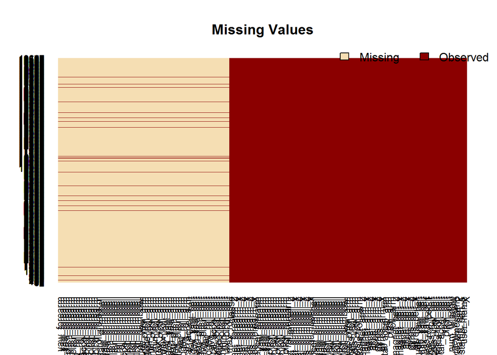

```r
rawTraining <- read.csv("https://d396qusza40orc.cloudfront.net/predmachlearn/pml-training.csv", stringsAsFactors = FALSE)
rawTesting <- read.csv("https://d396qusza40orc.cloudfront.net/predmachlearn/pml-testing.csv", stringsAsFactors = FALSE)

missmap(rawTraining, main="Missing Values")
```

As you can see, around half of the variables have most observations, but some of the variables are missing most observations. If we include them, they’ll increase the bias in our model, so lets remove them by filtering out variables where more than 50% of the observations are missing. We can them remove those variables from both the training and testing dataset, as well as the variables which aren’t relevant to us (such as the timestamp and username).

```r
missingVariables <- sapply(rawTraining, function(x)sum(is.na(x))<(length(x)*0.5)&&sum(x=="")<(length(x)*0.5))
training <- rawTraining[missingVariables] %>%
  select(-X, -user_name, -raw_timestamp_part_1, -raw_timestamp_part_2, -cvtd_timestamp, -new_window, -num_window)
training$classe <- factor(training$classe)

testing <- rawTesting[missingVariables] %>%
  select(-X, -user_name, -raw_timestamp_part_1, -raw_timestamp_part_2, -cvtd_timestamp, -new_window, -num_window)
```

### Part 2: Model Selection

Now let’s train a random-forest model to use on the test set. To test our model, lets use 10-fold cross validation from the caret package. We can later use this to evalute the performance of our model and predict the expected out of sample error. Ideally we want the expected out of sample error to be less that 5%, which means that we would expect no error when predicting the 20 test cases.

```r
set.seed(334)
##Sets up 10-fold cross validation
trainControl <- trainControl(method="cv", number=10)
rfModel <- train(classe~., data=training, trControl=trainControl)
rfModel
```

```
## Random Forest
##
## 19622 samples
##    52 predictor
##     5 classes: 'A', 'B', 'C', 'D', 'E'
##
## No pre-processing
## Resampling: Cross-Validated (10 fold)
## Summary of sample sizes: 17660, 17661, 17659, 17658, 17659, 17660, ...
## Resampling results across tuning parameters:
##
##   mtry  Accuracy   Kappa
##    2    0.9947003  0.9932958
##   27    0.9949039  0.9935535
##   52    0.9904701  0.9879441
##
## Accuracy was used to select the optimal model using  the largest value.
## The final value used for the model was mtry = 27.
```

As you can see, the accuracy for the model (based on the 10-fold cross validation) is 0.9949, suggesting that the model has an out of sample error of 1-0.9949=0.0051. This means that we expect the results of all 20 test cases to be correct, as intended.

We can find the predictions as follows:

```r
predict(rfModel, testing)
```

```
##  [1] B A B A A E D B A A B C B A E E A B B B
## Levels: A B C D E
```

### Bibliography

Ugulino, W.; Cardador, D.; Vega, K.; Velloso, E.; Milidiu, R.; Fuks, H. Wearable Computing: Accelerometers’ Data Classification of Body Postures and Movements. Proceedings of 21st Brazilian Symposium on Artificial Intelligence. Advances in Artificial Intelligence - SBIA 2012. In: Lecture Notes in Computer Science. , pp. 52-61. Curitiba, PR: Springer Berlin / Heidelberg, 2012. ISBN 978-3-642-34458-9. DOI: 10.1007/978-3-642-34459-6_6.

Read more: http://groupware.les.inf.puc-rio.br/har#ixzz4djxgN3gB